# Status loss and participation

## Status loss, continued participation

Stack Overflow · Main findings

Research discussion · October 2026

## Agenda

1. **Starting point** · activity analysis by Inna and Mario
2. **Comparability** · matching, sample selection, balance and time baselines
3. **Continuous-treatment approach** · supported shifts in relative reputation loss
4. **Comment text and context** · tone, focal emotions and opportunities to thank
5. **Conclusions and validation priorities**

## Reputation loss: activity, expression and context

### Contribution

Do users contribute more or less?

### Expression

Do tone and emotions change?

### Context

Where do users express thanks?

The 2010 policy change reduced question-upvote rewards from **+10 to +5** and applied retroactively. The analysis reconstructs each user’s reputation loss from their question-vote history before implementation.

**Treated:** users with the measured reputation loss. **Comparison:** users without that loss; they may still ask questions. The comparison is not exposure versus no exposure to every part of the policy change. [Rule change, March 19, 2010](https://stackoverflow.blog/2010/03/19/important-reputation-rule-changes/) · [Recalculation, March 21](https://stackoverflow.blog/2010/03/21/the-great-reputation-recalc-begins/).

## 1 · Activity analysis

Activity descriptives and DiD: no control, weekly volume, or days with other activities.

## Activity before and after the reform

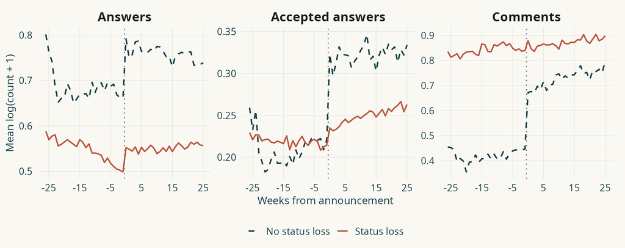

Weekly mean of log(count + 1) by group, ±26 weeks, as in code/analysis/02_descriptive.R. Only active user-weeks (any question, answer or comment); 85,605 users. Dashed petrol: no status loss; solid terracotta: status loss. Week 0 is the first seven days after announcement.

Weekly mean of log(count + 1) by group, ±26 weeks, as in code/analysis/02_descriptive.R. Only active user-weeks (any question, answer or comment); 85,605 users. Dashed petrol: no status loss; solid terracotta: status loss. Week 0 is the first seven days after announcement.

**Descriptive levels, not effects.** Groups differ before the reform and both shift at the announcement; the models compare these changes.

## Three specifications of weekly activity

```r
# CONTROL 1: number of contributions per user-week (accepted answers are in a).
d[, weekly_activity_volume := q + a + c]

# CONTROL 2: distinct active days with OTHER contribution types (0..7).
# x contains contribution timestamps aligned to the original t_week/activity_day.
days = x[, .(
  days_questions_answers = uniqueN(activity_day[post_type %in% c("question", "answer")]),
  days_questions_comments = uniqueN(activity_day[post_type %in% c("question", "comment")])
), by = .(user_id, t_week)]
d = merge(d, days, by = c("user_id", "t_week"), all.x = TRUE)
d[is.na(days_questions_answers), days_questions_answers := 0L]
d[is.na(days_questions_comments), days_questions_comments := 0L]
# Comments use Q/A days; answers and accepted answers use Q/comment days.
control_for = c(c_log = "days_questions_answers", a_log = "days_questions_comments",
               aa_log = "days_questions_comments")

# THREE SEPARATE MODELS: each adjusted model uses ONE of the two controls.
xformulas = list(no_control = ~1,
                 volume = ~weekly_activity_volume,
                 active_days = reformulate(control_for[[outcome]]))
# att_gt(..., xformla = xformulas[[specification]])
```

**Input.** `d`: observed user-weeks; `x`: dated questions, answers and comments.

**Objects.** `days`: distinct days by user-week. Merge into `d`; `control_for` selects the other-activity measure for each outcome.

**Result.** `xformulas`: three alternative formulas. The two controls never enter together; `37` fits the comparison matrix.

Code excerpt: `36_weekly_active_days_models.R → 37_psm_activity_reestimate.R`. Objects are prepared by the full script.

**Three separate models:** no control, weekly volume, or days with other activities. Both controls refer to the outcome week; they never enter together. Adjusted results are conditional comparisons.

## Unmatched DiD: comparison and uncertainty

```r
# Same call as the current PSM comparison; no-matching weights start at one.
z[, `:=`(observation_id = .I, user_cluster = user_id,
         time = t_week, g = treated, case_weight = 1)]
X = switch(specification,
  "No activity control" = ~1, "Weekly total contributions" = ~weekly_activity_volume,
  "Days with other contributions" = reformulate(control_for[[outcome]]))
fit = att_gt(yname = outcome, tname = "time", idname = "observation_id",
  gname = "g", data = z, panel = FALSE, clustervars = "user_cluster",
  weightsname = "case_weight", xformla = X,
  est_method = "reg", control_group = "nevertreated", anticipation = 0,
  base_period = "varying", bstrap = TRUE, biters = 1000, cband = TRUE)
```

**Input.** `z`: original observed user-weeks; weights equal one in the unmatched weekly model.

**Objects.** `observation_id` identifies a row; `user_cluster` identifies the person; `X` selects one outcome formula.

**Result.** `fit`: group-time estimates. `aggte` extracts average and weekly effects for the result tables and plots.

Code excerpt: `37_psm_activity_reestimate.R`. Objects are prepared by the full script.

85,605 users; 452,116 observed active user-weeks. No direct history covariates in the unmatched main model. No added inactive weeks; uncertainty grouped by user.

## Unmatched DiD: negative relative change in comments

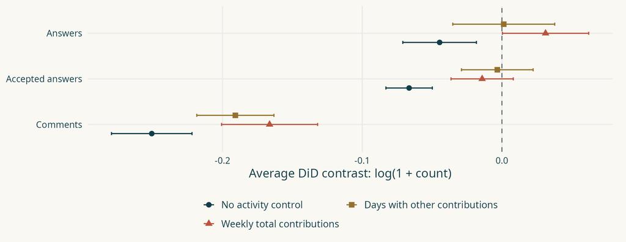

Unmatched DiD; identical sample and outcome-regression estimator. Point estimates and 95% intervals on log(1 + count).

Unmatched DiD; identical sample and outcome-regression estimator. Point estimates and 95% intervals on log(1 + count).

**Main model, last pre week:** treated +0.032; comparison +0.283; DiD **−0.251** in log(1 + comments). Both increase; comparison users increase more. Weekly-activity adjustments are separate conditional checks.

## Weekly DiD: answers

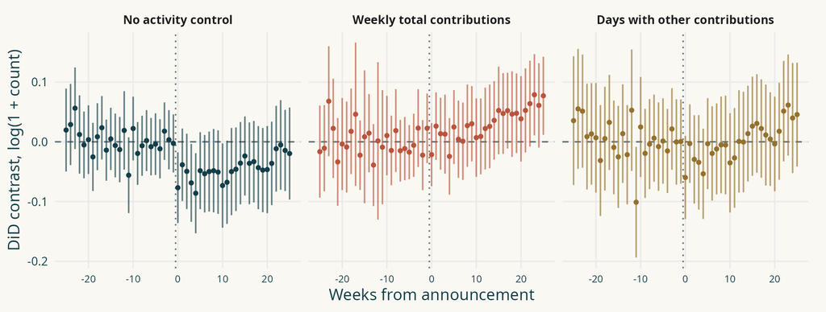

Same vertical scale across specifications. Simultaneous 95% bands within each fitted event study; no joint correction across specifications.

Same vertical scale across specifications. Simultaneous 95% bands within each fitted event study; no joint correction across specifications.

Read pre-period contrasts and post-period persistence separately; average effects need not describe every week.

## Weekly DiD: accepted answers

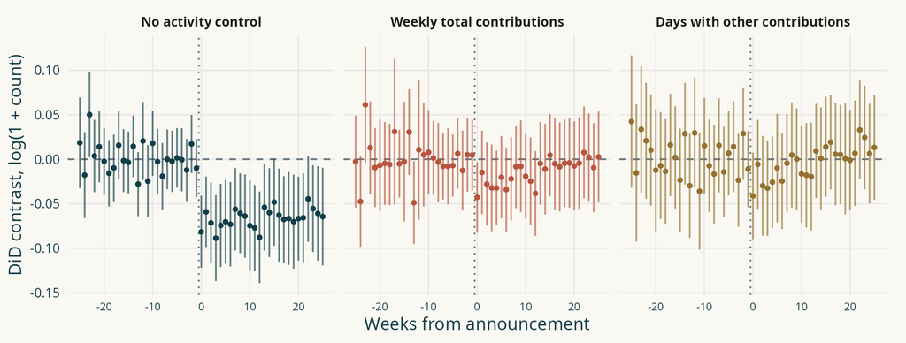

Same vertical scale across specifications. Simultaneous 95% bands within each fitted event study; no joint correction across specifications.

Same vertical scale across specifications. Simultaneous 95% bands within each fitted event study; no joint correction across specifications.

Read pre-period contrasts and post-period persistence separately; average effects need not describe every week.

## Weekly DiD: comments

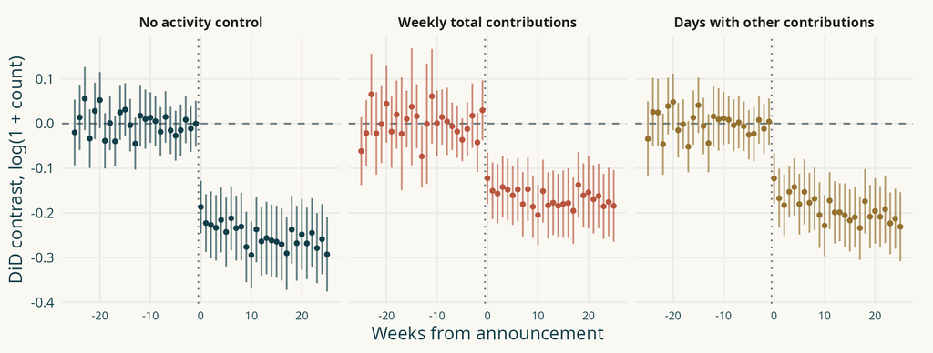

Same vertical scale across specifications. Simultaneous 95% bands within each fitted event study; no joint correction across specifications.

Same vertical scale across specifications. Simultaneous 95% bands within each fitted event study; no joint correction across specifications.

Read pre-period contrasts and post-period persistence separately; average effects need not describe every week.

## 2 · Matching

Balance pre-policy characteristics through selection and weights, then compare outcome changes. Both replacement designs remain in the main analysis.

## PSM 1:1 uses original prior-history variables

```r
covs = c("pre_comments", "tenure", "reputation_pre", "n_answers_pre")
base_args = list(formula = reformulate(covs, response = "treated"),
  data = frame, method = "nearest", distance = "glm", link = "linear.logit",
  estimand = "ATT", ratio = 1,
  caliper = c(0.2, reputation_pre = 0.2, n_answers_pre = 0.2),
  std.caliper = TRUE, mahvars = reformulate(covs))
m1 = do.call(matchit, c(base_args, list(replace = FALSE, m.order = "closest")))
# match.data(m1) supplies retained IDs and matching weights.
```

**Input.** `frame`: one row per eligible user; `covs`: four prior-history variables in original units.

**Objects.** `base_args`: propensity model, Mahalanobis inputs and calipers. `m1`: fitted 1:1 match without replacement.

**Result.** `match.data(m1)`: retained users and weights. These are joined to observed outcomes before fitting DiD.

Code excerpt: `37_psm_activity_reestimate.R`. Objects are prepared by the full script.

34,216 matched pairs; **69.0% of eligible treated users retained**. No log/asinh predictors and no prior-question eligibility or matching variable. Standardized calipers are distance limits, not transformed inputs.

## PSM with replacement reuses eligible controls

```r
# Same four variables, propensity model, Mahalanobis inputs and calipers.
m2 = do.call(matchit, c(base_args, list(replace = TRUE)))
users = as.data.table(match.data(m2))[, .(user_id, treated, weight = weights)]
# Reused controls are represented once with their matching weight.
ess = users[, .(users = .N,
                effective_n = sum(weight)^2 / sum(weight^2)), by = treated]
```

**Input.** The same `frame` and `base_args`; replacement is now allowed.

**Objects.** `m2`: fitted replacement match. `users`: one row per retained person, with their matching weight.

**Result.** `ess`: effective sample size by treatment group. Coverage and weight concentration are diagnostics, not DiD effects.

Code excerpt: `37_psm_activity_reestimate.R`. Objects are prepared by the full script.

47,838 treated users retained (**96.5%**), with 10,410 distinct eligible controls. Control effective N: **1,686**. Reuse increases coverage while concentrating weights.

## Three populations and two time baselines

| Population | Matching | Activity outcomes |
| --- | --- | --- |
| No matching | All eligible users with observed weeks | Answers, accepted answers, comments |
| PSM 1:1 | Original-unit history; no replacement | Same outcomes and original weeks |
| PSM with replacement | Same inputs and calipers; reused controls | Same outcomes and original weeks |

**Both matching designs are main comparisons.** The initial unmatched weekly-control comparison is separate. Two time baselines: last pre week, or all pre weeks with equal-week weights. No contemporary activity covariates enter these main DiD models.

## Time baselines: how the comparisons are built

```r
z = merge(d, matched_ids[, .(user_id, match_weight = weight)], by = "user_id")
z[, `:=`(observation_id = .I, user_cluster = user_id)]
# Weekly model: last pre week is the comparison base.
z[, `:=`(time = t_week, g = treated, case_weight = match_weight)]
# Broad-pre model: formal two-period DiD, equal weight per observed group-week.
z[, `:=`(time = ifelse(t_week < 0, 1L, 2L), g = 2L * treated)]
z[, case_weight := match_weight / sum(match_weight), by = .(treated, t_week)]
z[, case_weight := case_weight / uniqueN(t_week), by = .(treated, time)]
```

**Input.** `d`: weekly outcomes; `matched_ids`: retained users and weights for one design.

**Objects.** `z`: their joined records. The weekly and broad-pre blocks are alternative preparations, not consecutive models.

**Result.** `time`, `g`, `case_weight`: the time coding, treatment timing and observation weights passed to `att_gt`.

Code excerpt: `37_psm_activity_reestimate.R`. Objects are prepared by the full script.

The broad-pre model keeps original weekly observations and covariates. It gives each week equal weight within each group-period; it does not first collapse data to user-period means.

## DiD estimation: weights, covariates and outputs

```r
fit = att_gt(yname = outcome, tname = "time", idname = "observation_id",
  gname = "g", data = z, panel = FALSE, clustervars = "user_cluster",
  weightsname = "case_weight", xformla = ~1,
  est_method = "reg", control_group = "nevertreated", anticipation = 0,
  base_period = "varying", bstrap = TRUE, biters = 1000, cband = TRUE)
average = aggte(fit, type = "simple")
# Weekly-reference models also use aggte(fit, type = "dynamic").
```

**Input.** Prepared `z`; matching enters through `case_weight`. `xformla = ~1`: no contemporary activity covariate.

**Objects.** `fit`: group-time effects; `average`: aggregated effect. A separate dynamic aggregation supplies weekly estimates.

**Result.** 18 primary average comparisons → `activity_average_estimates.csv`; weekly-reference estimates → `activity_weekly_estimates.csv`.

Code excerpt: `37_psm_activity_reestimate.R`. Objects are prepared by the full script.

Repeated-cross-section estimation with original-user clustering. Average intervals: ±1.96 × SE. Weekly plots use each event study’s simultaneous critical value. Matching is held fixed in inference.

## Which model versions and controls are shown?

| Model block | Matching weights | Outcome-stage covariates |
| --- | --- | --- |
| Current activity: no matching | Equal user weights before reference weighting | Three alternatives: none, weekly volume, or other-activity days |
| Current activity: PSM 1:1 or replacement | Raw-unit matching weights, plus reference weighting | None (`~1`); prior balance enters through matching |
| Binary text and context | Text/context-specific PSM / CEM weights | Saved text/context specifications |
| Continuous-loss GAM | No binary matching weights | Six raw-scale pre-policy variables + pre-outcome mean |

Unmatched DiD shows the three weekly alternatives. Matched DiD adds neither weekly control. Activity PSM and raw-covariate positive-loss-target averages are updated. **Binary text/context matching still uses earlier weights.** Weekly activity is updated in the main slides; the appendix preserves the broader target and older dose fits.

## Eligible matching users and observed outcomes differ

| Design | Eligible T / C | Observed activity T / C | Treated retained | Eligible control ESS |
| --- | --- | --- | --- | --- |
| No matching | 49,588 / 47,071 | 43,906 / 41,699 | 100% | 47,071 |
| PSM 1:1 | 34,216 / 34,216 | 30,601 / 28,855 | 69.0% | 34,216 |
| PSM with replacement | 47,838 / 10,410 | 42,160 / 8,092 | 96.5% | 1,686 |

Original eligible frame and observed active weeks. No tenure, pre-activity or prior-question eligibility filter; no added zero weeks. ESS shown for eligible matched controls.

## Replacement expands treated-user coverage

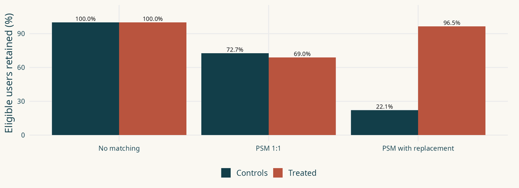

Retention in the original eligible frame. Same raw-unit predictors and standardized calipers; no question-history restriction.

Retention in the original eligible frame. Same raw-unit predictors and standardized calipers; no question-history restriction.

**Both designs are main comparisons:** without replacement retains 69.0% of treated users; replacement retains 96.5%. Compare coverage, balance and effective sample size together.

## Excluded treated users were much more active

| Pre-reform mean among treated users | Retained | Excluded |
| --- | --- | --- |
| Comments | 1.52 | 15.31 |
| Answers | 3.62 | 26.95 |
| Reputation | 90 | 788 |

Current raw-unit PSM 1:1: 34,216 eligible treated users retained; 15,372 excluded. Arithmetic means in original units, before outcome availability filters.

**Without replacement excludes 31% of eligible treated users**, who were more active on average. Its result applies to retained users, not automatically to all treated users. Both matching designs remain in the main analysis.

## Both raw-unit PSM designs balance the four inputs

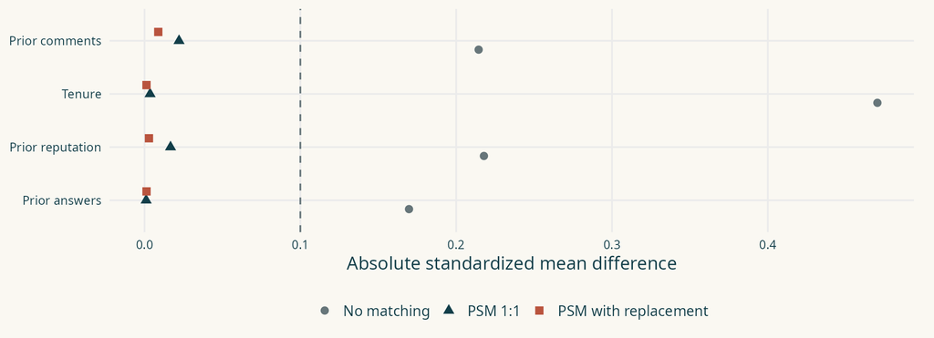

Absolute standardized mean differences; fixed pooled-SD denominator from the original eligible frame. Dashed 0.10 line is diagnostic, not a test.

Absolute standardized mean differences; fixed pooled-SD denominator from the original eligible frame. Dashed 0.10 line is diagnostic, not a test.

Maximum imbalance: 0.0222 for PSM 1:1 and 0.0089 with replacement. Balance in these inputs does not establish parallel trends.

## Observed comments before estimating effects

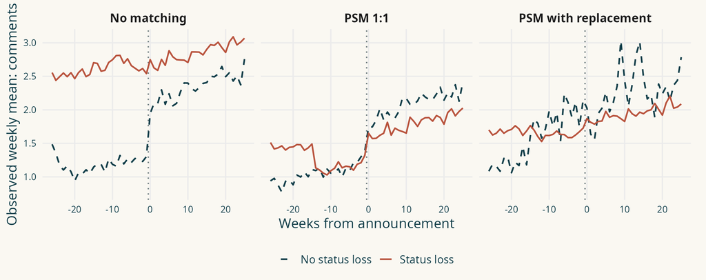

Design-weighted mean counts among original observed active user-weeks; common vertical scale across populations. These are levels, not estimated effects.

Design-weighted mean counts among original observed active user-weeks; common vertical scale across populations. These are levels, not estimated effects.

Compare pre-period trajectories, post-period changes and the changing observed composition separately.

## Observed answers before estimating effects

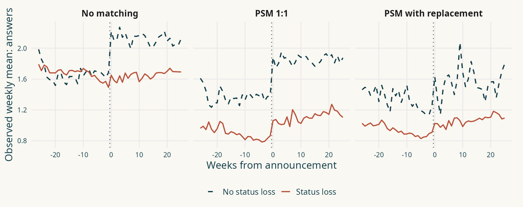

Design-weighted mean counts among original observed active user-weeks; common vertical scale across populations. These are levels, not estimated effects.

Design-weighted mean counts among original observed active user-weeks; common vertical scale across populations. These are levels, not estimated effects.

Compare pre-period trajectories, post-period changes and the changing observed composition separately.

## Observed accepted answers before estimating effects

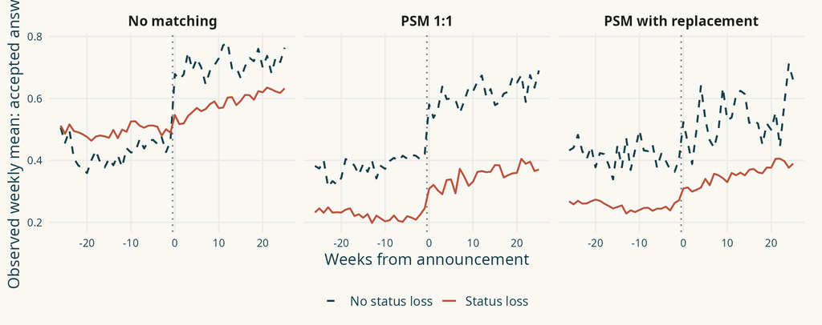

Design-weighted mean counts among original observed active user-weeks; common vertical scale across populations. These are levels, not estimated effects.

Design-weighted mean counts among original observed active user-weeks; common vertical scale across populations. These are levels, not estimated effects.

Compare pre-period trajectories, post-period changes and the changing observed composition separately.

## Different group changes produce different contrasts

| No activity control · comments | Treated change | Control change | DiD |
| --- | --- | --- | --- |
| No matching | +0.032 | +0.283 | −0.251 |
| PSM 1:1 | +0.105 | +0.141 | −0.035 |
| PSM with replacement | +0.029 | −0.008 | +0.038 |

Weighted post-week mean minus last pre-week mean, log(1 + comments). These group changes reconstruct the corresponding fitted unadjusted contrasts.

The full-sample negative contrast reflects a larger increase in controls. Selection and replacement weights change that comparison; both PSM last-week intervals include zero.

## Comments depend on the time baseline

| Comments · no activity control | Last pre week | All pre weeks |
| --- | --- | --- |
| No matching | −0.251 [−0.280, −0.222] | −0.280 [−0.300, −0.259] |
| PSM 1:1 | −0.035 [−0.071, +0.0001] | −0.124 [−0.148, −0.100] |
| PSM with replacement | +0.038 [−0.089, +0.164] | −0.077 [−0.130, −0.024] |

Formal DiD estimates and 95% intervals, conditional on the fitted matching. Broad-pre specification uses equal group-week weighting and user clustering.

Both PSM designs show a negative comments contrast with the broad-pre reference. The positive earlier descriptive result is not the current raw-unit PSM estimate.

## Matching balances prior variables; DiD compares changes

| What the new comparison establishes | What still limits interpretation |
| --- | --- |
| Both raw-unit designs balance the four pre-policy variables. | Other histories and pre-trends can still differ. |
| Without replacement retains 69% of treated users. | Excluded users were more active; the target population changes. |
| Replacement retains 96.5% of treated users. | Reused controls concentrate weights; control ESS falls. |
| Two fitted time baselines show reference sensitivity. | Parallel counterfactual trends remain an identifying assumption. |

**Neither matching design is automatically preferred.** We report both: differences can reflect the treated population, comparison weights and precision. User-cluster intervals hold matching fixed.

## Activity DiD: both time baselines

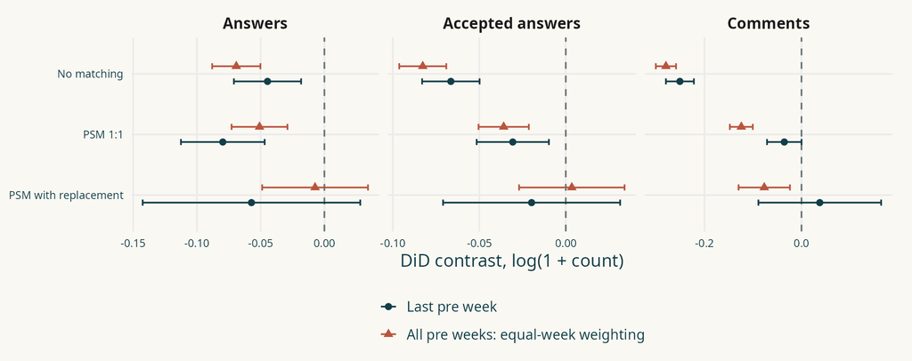

Three populations; both fitted references; 95% user-cluster multiplier intervals conditional on matching. Effects in log(1 + count).

Three populations; both fitted references; 95% user-cluster multiplier intervals conditional on matching. Effects in log(1 + count).

Broad-pre PSM 1:1: answers, accepted answers and comments are negative with intervals excluding zero.

## Weekly answers

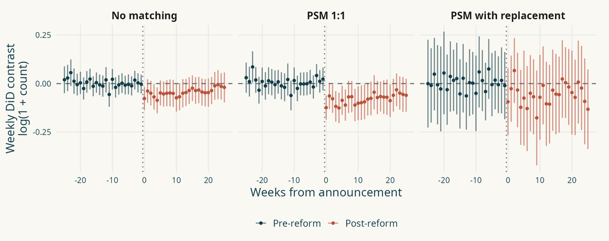

Weekly-reference event studies; identical vertical scale across populations. Simultaneous 95% bands within each model.

Weekly-reference event studies; identical vertical scale across populations. Simultaneous 95% bands within each model.

Read pre-period patterns and post-period persistence; these are weekly contrasts, not the two-period broad-pre model.

## Weekly accepted answers

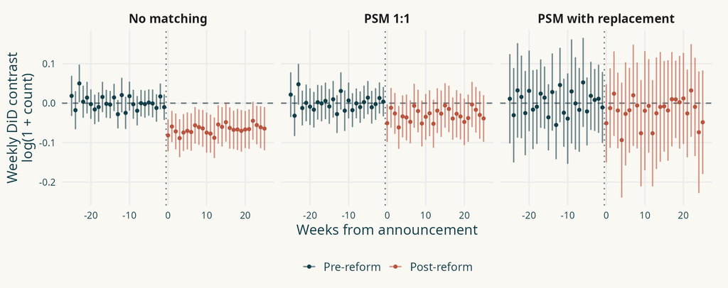

Weekly-reference event studies; identical vertical scale across populations. Simultaneous 95% bands within each model.

Weekly-reference event studies; identical vertical scale across populations. Simultaneous 95% bands within each model.

Read pre-period patterns and post-period persistence; these are weekly contrasts, not the two-period broad-pre model.

## Weekly comments

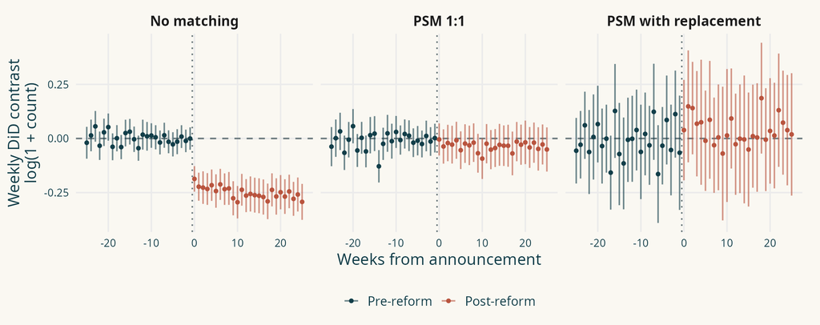

Weekly-reference event studies; identical vertical scale across populations. Simultaneous 95% bands within each model.

Weekly-reference event studies; identical vertical scale across populations. Simultaneous 95% bands within each model.

Read pre-period patterns and post-period persistence; these are weekly contrasts, not the two-period broad-pre model.

## Continuous treatment: activity

Among users who actually lost reputation, what changes with a larger loss? Fit all eligible users; average where data support the proposed increase.

## Two questions; one main population

| Role | Question | Who enters the average? |
| --- | --- | --- |
| **Main** | Among users who lost reputation, what changes with a larger loss? | Observed loss **greater than zero**, with support for the increment |
| **Appendix** | What changes with a larger loss among all supported users? | Includes users with **zero** observed loss |

We choose the first question to study **loss intensity among users who actually lost reputation**. The earlier, broader analysis remains in the appendix.

All eligible users with valid outcomes can inform fitting. The main model uses raw prior covariates; the appendix preserves the earlier broader target with transformed covariates. That broader question includes transitions from no loss to a positive loss.

## Continuous treatment: shifts in relative loss

How does activity change with **15 percentage points more loss**, among users who actually lost reputation?

| Role | Model | What it allows |
| --- | --- | --- |
| **Main** | Additive GAM | The relationship can curve across loss levels. |
| **Appendix** | Linear dose × prior history | The loss slope can differ across prior histories, but stays constant across doses for a given history. |

The main GAM uses **six prior characteristics in their original units**, plus the pre-outcome mean. At the same starting loss, its shift contrast does not vary with history; the appendix model allows those interactions.

Same supported positive-loss question in both models. Dose = points lost / max(pre-policy reputation + 1, 1). +15 pp is focal; +5 to +25 pp are shown. Activity outcomes retain log(1 + count).

## What was this user like before the reform?

| What we control for | How we build it | Why it matters |
| --- | --- | --- |
| Prior activity | Three pre-announcement counts: comments, questions and answers | Heavy and occasional contributors start differently. |
| Prior reputation | Reputation before the announcement | Users start with different status. |
| Experience | Weeks from recorded user start to the announcement | New and established users may behave differently. |
| Asking vs answering | Pre-announcement questions / (questions + answers) | Users differ in their type of contribution. |
| Starting outcome | Mean pre-policy weekly outcome for that user | Compare changes given where the user started. |

**Six prior-history variables + one outcome baseline.** These are adjustment variables, not matched control users. We hold them fixed in both predictions; no current-week activity control enters.

Prior counts, reputation, experience and question share enter in their original units. Outcome baseline: mean of observed weekly log(1 + count). Exact construction follows in the code slide.

## Support means data near the higher loss

Example: a user lost **10%**. A **+15-pp** contrast needs information near **25% loss**.

| For this increment | What the data show | What we do |
| --- | --- | --- |
| **With support** | Enough users near 25% loss in the same broad prior-history group | Include the user in the +15-pp average |
| **Without support** | Too few such observations near 25% | Leave the user out of this average to limit extrapolation |

Support depends on the proposed increase: a user may qualify for +5 pp but not +15 pp. **No support does not mean no reputation loss.**

Our rule: ≥5 users in the 2.5-pp dose bin containing the shifted loss, within the same coarse history stratum. They are not exact matches. This practical check does not guarantee causal comparability.

## Compare the same history with 15 pp more loss

| Illustrative user | Loss used in first prediction | Loss used in second prediction |
| --- | --- | --- |
| A | 10% | 25% |
| B | 30% | 45% |

1. **Learn:** fit outcomes across eligible users with different losses, adjusting for prior history.
2. **Compare:** predict twice for each supported user with positive observed loss; change only their loss.
3. **Average:** shifted prediction minus observed-dose prediction, among supported users with positive observed loss.

There is **no single matched control user**, and comparison is not limited to zero-loss users. The alternative outcome is a model prediction, informed by observed users at different doses.

Support check: ≥5 users in the shifted 2.5-pp dose bin within the same broad history stratum. These are not five exact matches. Support and measured-history adjustment do not guarantee a causal interpretation.

## Support for each increment: main analysis

| Step | Main analysis | Why? |
| --- | --- | --- |
| Define the population | Users with **positive observed loss** | Study loss intensity among those actually affected |
| Check the proposed increase | Require support for **that increment** | Limit predictions with insufficient nearby data |
| Average the contrast | Use the users meeting both conditions | Target users can differ across increments |

A +15-pp comparison does not require support for +25 pp. Requiring all five increments is an additional restriction, retained only in the historical appendix.

Support uses the unchanged full eligible frame. Our 2.5-pp bins / ≥5 rule is a diagnostic heuristic, not a guarantee of causal identification. Lundberg & Brand (2026) motivate supported shifts; these thresholds and the positive-loss target are our choices.

## Who enters each dose-shift average?

| Increment | Activity target: positive loss | Text target: positive loss |
| --- | --- | --- |
| +5 pp | 12,478 | 8,663 |
| +10 pp | 9,117 | 6,035 |
| **+15 pp · focal** | **6,153** | **3,892** |
| +20 pp | 3,909 | 2,370 |
| +25 pp | 2,323 | 1,322 |

Everyone counted here has **observed loss >0 and support for this increment**. Zero-loss users help fit the model but do not enter the main average.

Training is unchanged: 25,218 activity / 15,982 text users with valid pre/post outcomes. “Activity” covers separate answers, accepted-answers and comments models. Targets are not a fixed population across increments.

## Continuous-dose controls use pre-reform history

```r
# Prior-history controls enter in ORIGINAL UNITS; no log/asinh transformations.
covariates = c("pre_comments", "tenure", "reputation_pre",
               "n_questions_pre", "n_answers_pre", "pct_questions_pre")
frame[, pct_questions_pre := fifelse(n_questions_pre + n_answers_pre > 0,
  n_questions_pre / (n_questions_pre + n_answers_pre), 0.5)]
# Counts and reputation precede the policy; tenure is in weeks.
# Outcome scale stays log(1 + weekly count); its baseline uses that same scale.
base = act[t_week < 0, .(base_comments = mean(comments)), by = user_id]
```

**Input.** Prior counts, reputation and experience; original observed weekly outcomes.

**Objects.** Six raw-scale history variables; `base_comments`: earlier mean of the outcome, not the historical comment total.

**Result.** Prior characteristics stay fixed when predicting observed loss and loss +15 pp. Target: positive observed loss and support.

We removed transformations of the **prior-history covariates**. The outcome and its baseline keep their established scale, so the shift contrast remains in the same units.

## Code behind the displayed dose estimates

```r
# act contains original OBSERVED active weeks; no added inactive-week zeros.
# period_delta(): each user's post mean minus pre mean; both periods required.
y = period_delta(act, c("answers", "accepted_answers", "comments"))
frame[, rel_loss := loss_points / pmax(reputation_pre + 1, 1)]
training = merge(frame, y, by = "user_id") # all eligible, valid pre/post outcomes
gam_fit = gam(comments ~ s(rel_loss, k=10) + s(pre_comments, k=6) +
    s(tenure, k=6) + s(reputation_pre, k=6) + s(n_questions_pre, k=6) +
    s(n_answers_pre, k=6) + s(pct_questions_pre, k=6) + s(base_comments, k=6),
    data = training, method = "REML")
target = training[rel_loss > 0 & supported_0.15 == TRUE]
shifted = copy(target)[, rel_loss := rel_loss + 0.15]
mean(predict(gam_fit, shifted) - predict(gam_fit, target))
# Fit once per outcome/model; use supported positive-loss target users for each increment.
# 200 user bootstraps; smoothing penalties held fixed during bootstrap refits.
```

**Input.** `act` → `y`: one pre/post change and baseline per user. `frame`: dose, earlier controls and support flags.

**Objects.** `training`: all eligible valid-outcome users; `gam_fit`: fitted relationships; `target` and `shifted`: prediction data.

**Result.** Mean shifted-minus-observed prediction → `estimates.csv`. `validation.csv` checks direct predictions and weighted refits.

Code excerpt: `44_relative_shift_raw_covariates.R and the fixed-basis helpers`. Objects are prepared by the full script.

**Completed specification:** fit all eligible valid-outcome users; average predictions only for supported positive-loss target users. Six history covariates + the pre-outcome level; no contemporary weekly-activity control.

## Model fitting and target population are different

| Step | Intuition |
| --- | --- |
| **Learn the pattern** | Fit the model with all eligible users with valid pre/post outcomes. |
| **Define the question** | Select users with positive observed loss and support for the chosen increment. |
| **Compare predictions** | Predict their change at actual loss and loss + increment; average the difference. |

```r
training = merge(frame, y, by = "user_id")  # all eligible, valid-outcome users
fit = gam(outcome_formula, data = training, method = "REML")
target = training[rel_loss > 0 & supported_0.15 == TRUE]   # only the averaging population
shifted = copy(target)[, rel_loss := rel_loss + 0.15]
mean(predict(fit, shifted) - predict(fit, target))
# User bootstrap refits use all training users; averages use target users only.
```

**Input.** `training`: 25,218 activity / 15,982 text users with valid pre/post outcomes.

**Objects.** `fit` learns the relationship; `target` selects supported users with observed loss >0; `shifted` changes their dose only.

**Result.** At +15 pp: average over 6,153 activity / 3,892 text users. `sample_plan.csv` records training and target sizes.

Code excerpt: `44_relative_shift_raw_covariates.R`. Objects are prepared by the full script.

**Completed and numerically checked.** Training: 25,218 activity / 15,982 text users. At +15 pp, averages use 6,153 / 3,892 supported users. Updated weekly activity follows; weekly text remains an earlier fit.

## How to read a continuous-dose effect

| Step | Meaning |
| --- | --- |
| Outcome | Each user’s post-policy mean minus pre-policy mean of log(1 + weekly count) |
| Contrast | Predicted outcome at loss +15 pp minus predicted outcome at observed loss |
| Negative value | A lower predicted activity change with the larger loss |
| Positive value | A higher predicted activity change with the larger loss |

The graph shows a **difference between two predicted changes**. Counts on the slide identify whose predictions enter the average; they are not extra model coefficients to interpret.

Main: GAM with raw prior-history covariates. Average only among supported users with positive observed loss. Emotion results use score points.

## Activity among users with loss: +5 pp

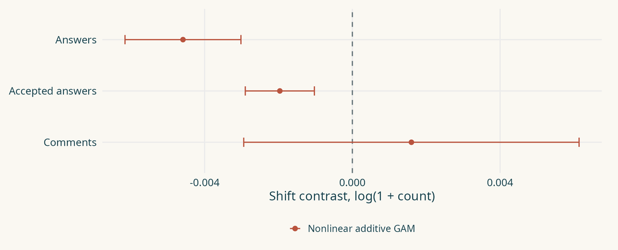

Main GAM; prior characteristics in original units. Average: 12,478 supported users with positive observed loss. Training: 25,218. 200 user draws; 95% pointwise intervals; fixed support and GAM basis/penalties.

Main GAM; prior characteristics in original units. Average: 12,478 supported users with positive observed loss. Training: 25,218. 200 user draws; 95% pointwise intervals; fixed support and GAM basis/penalties.

Answers and accepted answers have negative GAM intervals; the comment interval includes zero.

## Activity among users with loss: +10 pp

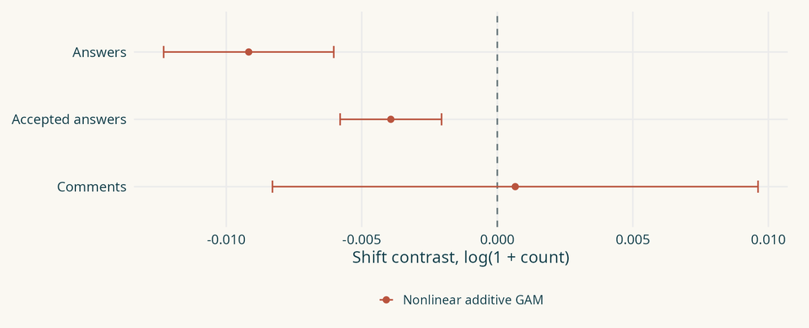

Main GAM; prior characteristics in original units. Average: 9,117 supported users with positive observed loss. Training: 25,218. 200 user draws; 95% pointwise intervals; fixed support and GAM basis/penalties.

Main GAM; prior characteristics in original units. Average: 9,117 supported users with positive observed loss. Training: 25,218. 200 user draws; 95% pointwise intervals; fixed support and GAM basis/penalties.

Answers and accepted answers have negative GAM intervals; the comment interval includes zero.

## Activity among users with loss: +15 pp

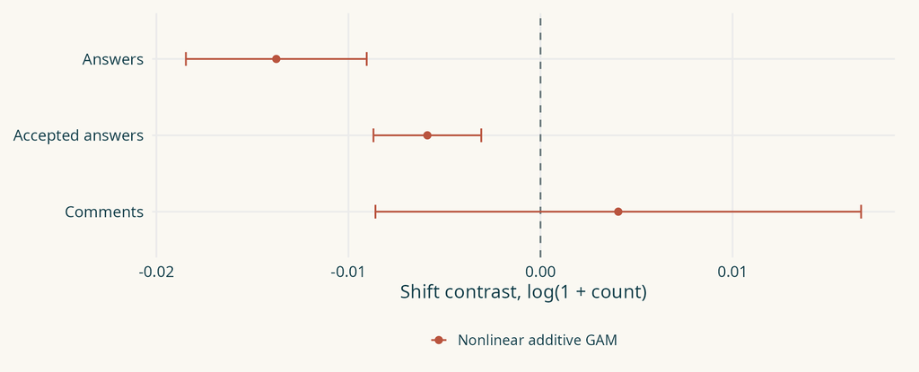

Main GAM; prior characteristics in original units. Average: 6,153 supported users with positive observed loss. Training: 25,218. 200 user draws; 95% pointwise intervals; fixed support and GAM basis/penalties.

Main GAM; prior characteristics in original units. Average: 6,153 supported users with positive observed loss. Training: 25,218. 200 user draws; 95% pointwise intervals; fixed support and GAM basis/penalties.

Answers and accepted answers have negative GAM intervals; the comment interval includes zero.

## Weekly +15-pp contrasts: construction and uncertainty

```r
# Weekly outcome: log(1 + count) minus this user's mean over observed pre weeks.
weekly = weekly_dev(act, c("answers", "accepted_answers", "comments"))
d = merge(frame, weekly, by = "user_id")[t_week == week]
fit = bam(formula, data = d, method = "fREML")  # six raw-scale prior controls + pre-outcome mean
target = copy(d[rel_loss > 0 & supported_0.15 == TRUE])
shifted = copy(target)[, rel_loss := rel_loss + 0.15]
mean(predict(fit, shifted) - predict(fit, target))
# Repeat by week/outcome; 200 shared user bootstraps, fixed basis/penalties/support.
```

**Input.** Original observed weekly activity and pre-policy histories. No added inactive weeks.

**Objects.** `d`: all eligible users with this observed week and a valid pre mean; `fit`: weekly additive GAM with raw prior covariates; `target`: supported users with positive observed loss in that week.

**Result.** 84 weekly GAMs; 95% **pointwise** intervals from 200 user draws. Direct predictions and an independent fixed-basis weighted QR refit numerically agree.

**Weekly question:** how does the +15-pp contrast vary over time? These trajectories use **only the additive GAM**, fitted separately each week. Pre-policy points are diagnostics; weekly samples change. They do not decompose the average effect or reproduce the binary DiD event study.

Training: 6,505–12,149 users per week; target: 1,316–2,577. Weekly text remains an earlier fit. Original panel week labels: −14…−1 and +1…+14.

## Weekly +15 pp among users with loss: answers

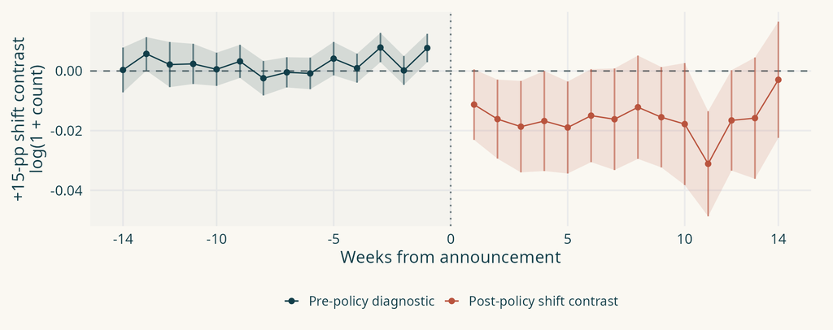

Weekly GAM with raw prior-history covariates; supported users with positive observed loss. 200 user draws; 95% pointwise intervals. Weekly samples change; pre-policy points are diagnostics.

Weekly GAM with raw prior-history covariates; supported users with positive observed loss. 200 user draws; 95% pointwise intervals. Weekly samples change; pre-policy points are diagnostics.

## Weekly +15 pp among users with loss: accepted answers

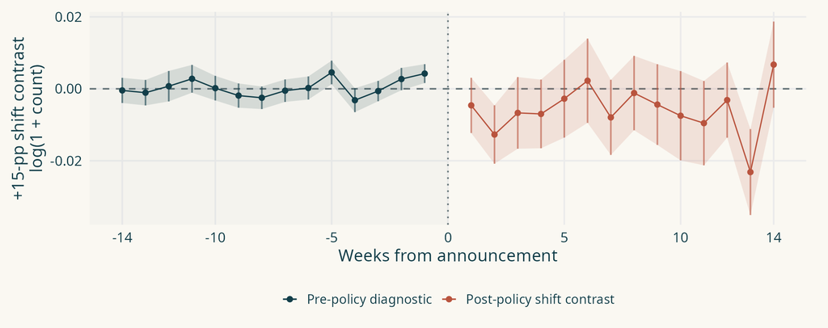

Weekly GAM with raw prior-history covariates; supported users with positive observed loss. 200 user draws; 95% pointwise intervals. Weekly samples change; pre-policy points are diagnostics.

Weekly GAM with raw prior-history covariates; supported users with positive observed loss. 200 user draws; 95% pointwise intervals. Weekly samples change; pre-policy points are diagnostics.

Accepted answers show negative intervals in two post-policy weeks; the remaining weeks include zero.

## Weekly +15 pp among users with loss: comments

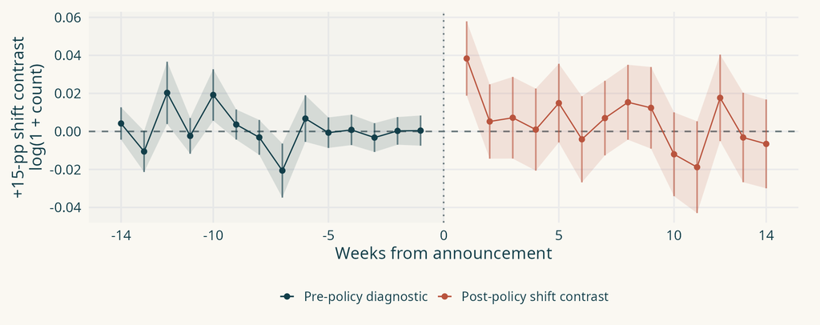

Weekly GAM with raw prior-history covariates; supported users with positive observed loss. 200 user draws; 95% pointwise intervals. Weekly samples change; pre-policy points are diagnostics.

Weekly GAM with raw prior-history covariates; supported users with positive observed loss. 200 user draws; 95% pointwise intervals. Weekly samples change; pre-policy points are diagnostics.

Only the first post-policy week has an interval above zero; the other post-policy intervals include zero.

## Activity among users with loss: +20 pp

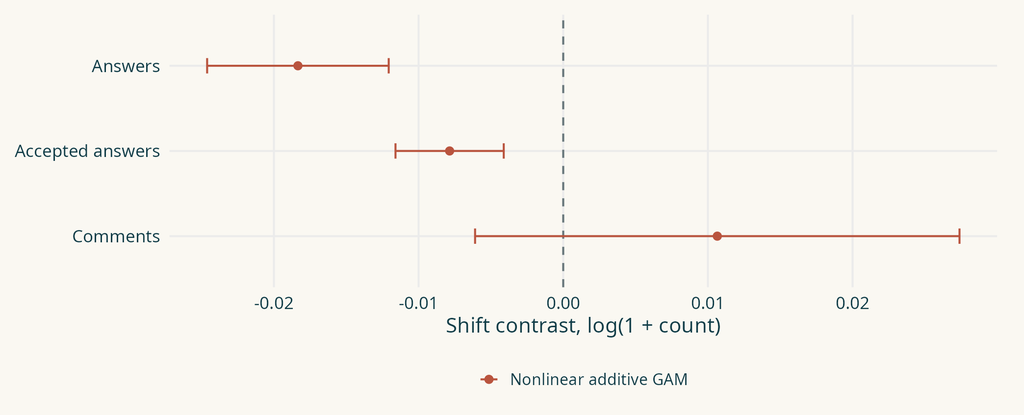

Main GAM; prior characteristics in original units. Average: 3,909 supported users with positive observed loss. Training: 25,218. 200 user draws; 95% pointwise intervals; fixed support and GAM basis/penalties.

Main GAM; prior characteristics in original units. Average: 3,909 supported users with positive observed loss. Training: 25,218. 200 user draws; 95% pointwise intervals; fixed support and GAM basis/penalties.

Answers and accepted answers have negative GAM intervals; the comment interval includes zero.

## Activity among users with loss: +25 pp

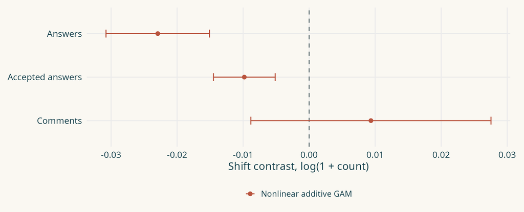

Main GAM; prior characteristics in original units. Average: 2,323 supported users with positive observed loss. Training: 25,218. 200 user draws; 95% pointwise intervals; fixed support and GAM basis/penalties.

Main GAM; prior characteristics in original units. Average: 2,323 supported users with positive observed loss. Training: 25,218. 200 user draws; 95% pointwise intervals; fixed support and GAM basis/penalties.

Answers and accepted answers have negative GAM intervals; the comment interval includes zero.

## 3 · Text analysis: DiD and matching

Comment tone and approval, admiration and gratitude scores: descriptives, DiD without matching, then matched comparisons.

## Two text measures: VADER and GoEmotions

| Measure | What is it? | What do we use? |
| --- | --- | --- |
| **VADER** | A sentiment dictionary plus language rules; measures overall positive / negative tone | Overall tone: **−1 to +1**; shares of positive and negative comments |
| **GoEmotions-based model** | A language model trained on human-labeled Reddit comments | **28 separate scores, 0–1**; main focus: approval, admiration and gratitude |

VADER measures **overall tone**; the GoEmotions-based model measures **specific expressions**. Scores describe the text, not the writer’s private feelings. Multiple emotion labels can apply to one comment.

PSM descriptives: 183,464 comments, 14 weeks per side. Average within user-week, then apply design weights. Positive: VADER ≥0.05; negative: ≤−0.05. GoEmotions: 27 emotions + neutral; scores need not sum to 1. No comment ≠ emotion zero.

Sources: [VADER](https://github.com/cjhutto/vaderSentiment); [GoEmotions model card](https://huggingface.co/SamLowe/roberta-base-go_emotions). Implementation: `03_sentiment.py`, `04_goemotions.py`, `31_corrected_designs.R`.

## Comment tone before and after the reform

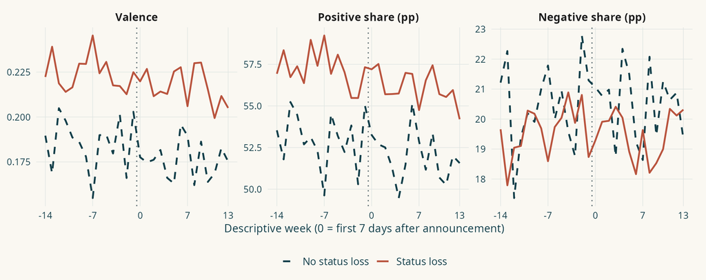

Weighted means of user-week scores in the PSM sample: VADER compound (−1 to +1), positive share (compound ≥ 0.05) and negative share (≤ −0.05), in %. First average within user-week, then apply design weights. Week 0 is the first seven days after announcement.

Text/context uses its own saved matching design; these models have not been re-estimated with the activity matches. Weighted means of user-week scores in the PSM sample: VADER compound (−1 to +1), positive share (compound ≥ 0.05) and negative share (≤ −0.05), in %. First average within user-week, then apply design weights. Week 0 is the first seven days after announcement.

**Matched descriptives, among observed commenters.** Weekly averages use the same user-week aggregation and design weights as the text analysis.

## Three focal emotions before and after

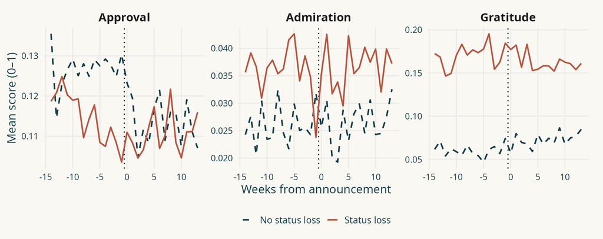

Weekly mean of Three focal score (0–1) among observed PSM-matched user-weeks. Dashed petrol: no status loss; solid terracotta: status loss. Panel scales differ. Larger versions in the appendix.

Text/context uses its own saved matching design; these models have not been re-estimated with the activity matches. Weekly mean of Three focal score (0–1) among observed PSM-matched user-weeks. Dashed petrol: no status loss; solid terracotta: status loss. Panel scales differ. Larger versions in the appendix.

Approval, admiration and gratitude are shown in original score units; compare estimates and intervals.

## Average users, then apply the comparison design

### Corpus by context

Each observed comment weighs one.  
Prolific authors contribute more.

### Matched descriptives and models

Average comments within each user-week.  
Then apply the design’s user weights.

**PSM:** retained users weigh 1. **CEM:** control weights reproduce the retained treated history mix. No comment means an undefined text outcome.

Text/context uses its own saved matching design; these models have not been re-estimated with the activity matches.

## Observed text can change with who participates

| Outcome | Observations entering the model | Missing participation |
| --- | --- | --- |
| Activity | Original observed active user-weeks | Missing weeks are not added |
| Weekly text | User-weeks with comments | No text outcome |
| Broad-reference text | Mean of observed weekly means per period | Users can appear in only one period |
| Context / first comment | Observed comments in that setting | No unobserved opportunity is added |

With `allow_unbalanced_panel = TRUE`, `did` 2.5.0 uses repeated-cross-section estimation when observations are missing. **Matching does not fix changing participation.**

Text/context uses its own saved matching design; these models have not been re-estimated with the activity matches.

## Text DiD without matching: model and average tone

```r
# Same user-week text outcomes as the matched models; all eligible observed users.
d = copy(txt)[, `:=`(g = treated, weight = 1)]  # txt: scored user-week means
fit = att_gt(yname = "valence", tname = "t_week", idname = "user_id",
             gname = "g", xformla = ~ 1, data = d,
             weightsname = "weight", est_method = "dr",
             allow_unbalanced_panel = TRUE)
# No matching weights or activity-intensity covariate in this text specification.
average = aggte(fit, type = "simple")
```

**Input.** Scored comments → `txt`: means by user and week. No comment means no observed text score.

**Objects.** `fit`: group-time estimates; `average`: aggregated effect. Dynamic aggregation gives weekly results; broad-pre fits user-period means.

**Result.** Text rows in `corrected_design_att.csv` and `corrected_design_dynamic.csv`; earlier text weights are used only in matched versions.

Code excerpt: `31_corrected_designs.R, saved text estimates`. Objects are prepared by the full script.

| Tone outcome | Last pre week [95% CI] | All pre weeks [95% CI] |
| --- | --- | --- |
| Valence | +0.004 [−0.018, 0.026] | −0.015 [−0.026, −0.003] |
| Positive share · pp | +0.324 [−2.174, 2.822] | −1.489 [−2.825, −0.152] |
| Negative share · pp | +1.512 [−0.291, 3.315] | +0.660 [−0.425, 1.745] |

40,669 users with comments. Same aggregation and DiD framework as the matched text models; outcome-stage covariates are an intercept.

## Unmatched text DiD: weekly tone

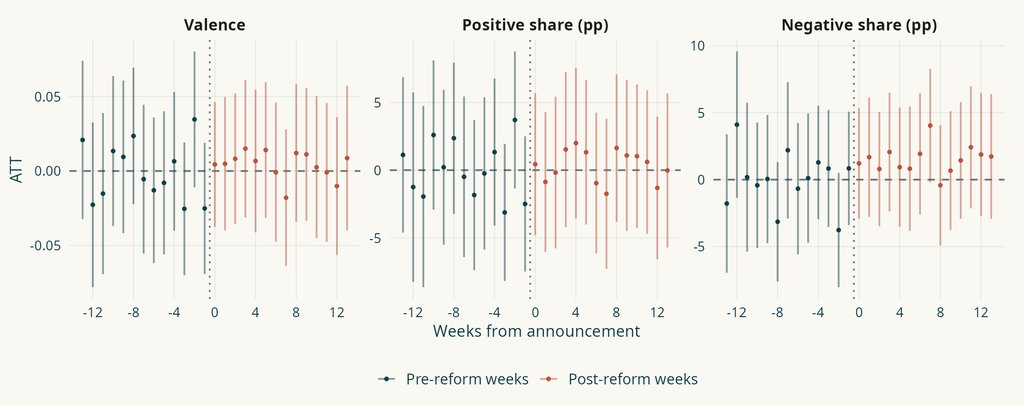

Unmatched DiD on user-week means; 40,669 users with comments. Simultaneous 95% bands within outcome; last-pre-week reference for post effects.

Unmatched DiD on user-week means; 40,669 users with comments. Simultaneous 95% bands within outcome; last-pre-week reference for post effects.

Weekly effects and average effects answer different summaries; broad-reference results appear in the comparison table.

## Unmatched DiD: weekly focal emotion effects

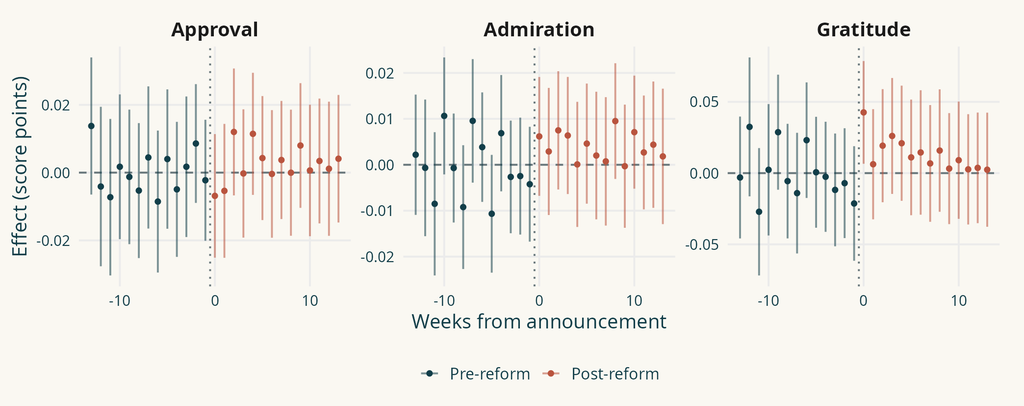

Weekly DiD without matching; emotion scores 0–1. Simultaneous 95% bands within label. All labels retained.

Weekly DiD without matching; emotion scores 0–1. Simultaneous 95% bands within label. All labels retained.

Approval, admiration and gratitude are shown in original score units; compare estimates and intervals.

## Unmatched DiD: average focal emotion effects

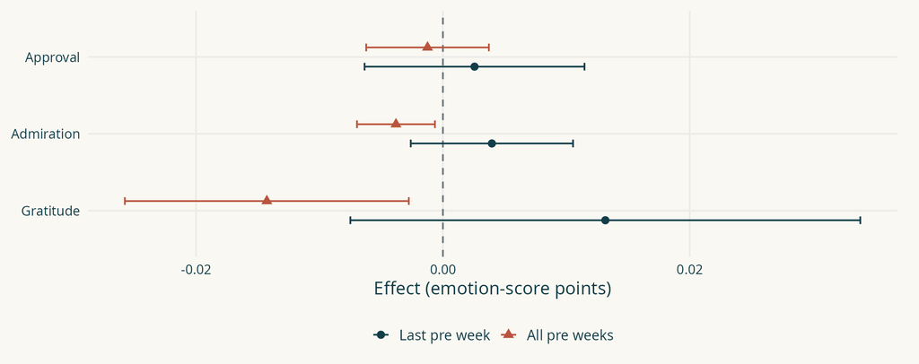

Unmatched average DiD; 40,669 users. Last pre week versus all pre weeks; 95% intervals, no joint multiplicity correction.

Unmatched average DiD; 40,669 users. Last pre week versus all pre weeks; 95% intervals, no joint multiplicity correction.

Approval, admiration and gratitude are shown in original score units; compare estimates and intervals.

## Matched tone: weekly bands include zero

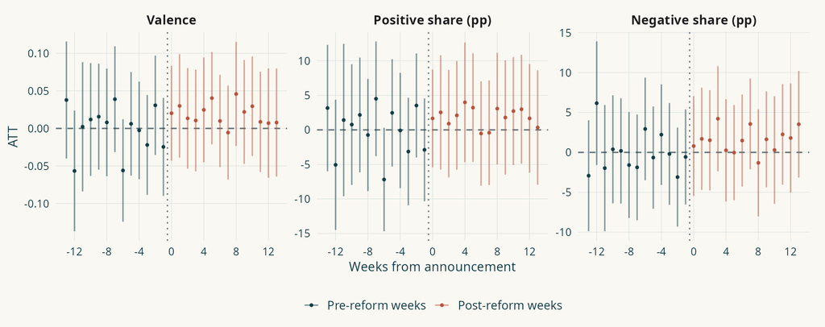

did dynamic ATT, PSM/Mahalanobis on the eligible analysis sample (13,593 pairs). Bars: simultaneous 95% bands. Post points compare with the last pre week; week 0 = first week after announcement. User-week means; weeks with comments only (7,077 treated users comment).

Text/context uses its own saved matching design; these models have not been re-estimated with the activity matches. did dynamic ATT, PSM/Mahalanobis on the eligible analysis sample (13,593 pairs). Bars: simultaneous 95% bands. Post points compare with the last pre week; week 0 = first week after announcement. User-week means; weeks with comments only (7,077 treated users comment).

The weekly tone estimates do not identify a clear shift; this is not proof of an exactly zero effect. Earlier text matching: 7,077 treated and 5,488 comparison users with comments.

## Matched average tone effects remain uncertain

| VADER outcome | Last pre week [95% CI] | All pre weeks [95% CI] |
| --- | --- | --- |
| Valence | +0.019 [−0.012, 0.050] | −0.005 [−0.023, 0.013] |
| Positive share · pp | +1.859 [−1.872, 5.590] | −1.195 [−3.249, 0.859] |
| Negative share · pp | +1.549 [−1.256, 4.353] | +0.008 [−1.671, 1.688] |

All six PSM tone intervals include zero. Text scores are observed only when users comment.

Text/context uses its own saved matching design; these models have not been re-estimated with the activity matches.

## PSM: weekly focal emotion effects

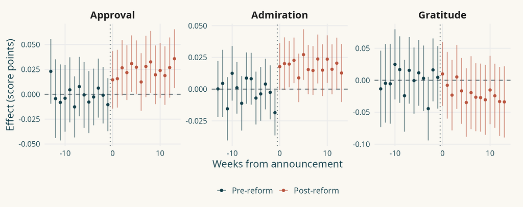

Approval, admiration and gratitude are shown in original score units; compare estimates and intervals.

## PSM: approval, admiration and gratitude

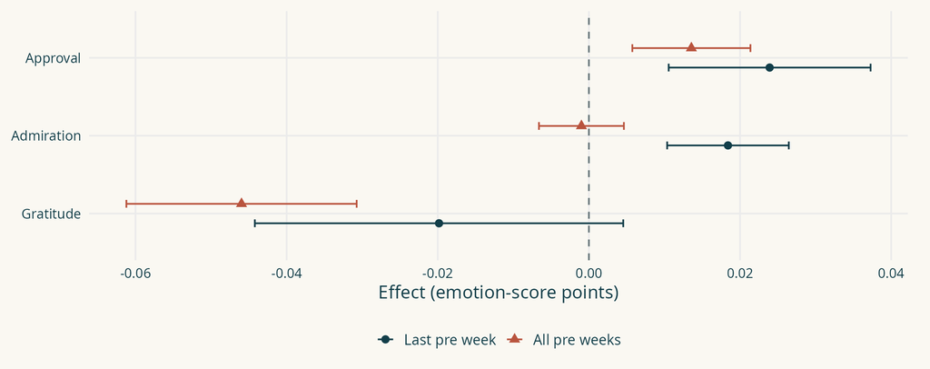

PSM/Mahalanobis average ATT on user-week mean scores (0–1), eligible analysis sample. Circles: reference = last pre week; triangles: all pre weeks. Bars: 95% intervals, no multiplicity correction.

Text/context uses its own saved matching design; these models have not been re-estimated with the activity matches. PSM/Mahalanobis average ATT on user-week mean scores (0–1), eligible analysis sample. Circles: reference = last pre week; triangles: all pre weeks. Bars: 95% intervals, no multiplicity correction.

Approval increases under both references; admiration and gratitude depend on the pre-period reference.

## Focal emotions across designs and references

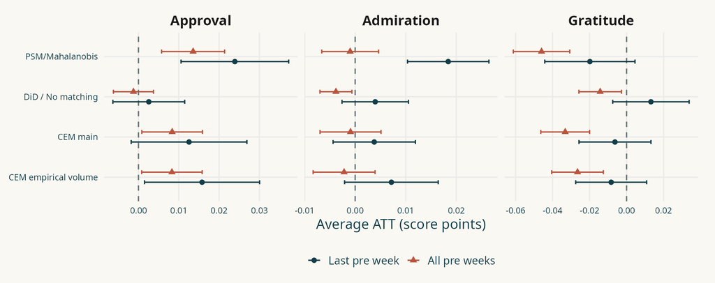

Average ATT on user-week means, four comparison designs (unmatched DiD, PSM and two CEM), eligible analysis sample. Circles: reference = last pre week; triangles: all pre weeks. Emotions in score points (0–1); VADER valence in points, shares in pp. Bars: 95% intervals.

Text/context uses its own saved matching design; these models have not been re-estimated with the activity matches. Average ATT on user-week means, four comparison designs (unmatched DiD, PSM and two CEM), eligible analysis sample. Circles: reference = last pre week; triangles: all pre weeks. Emotions in score points (0–1); VADER valence in points, shares in pp. Bars: 95% intervals.

Approval, admiration and gratitude are shown in original score units; compare estimates and intervals.

## Emotions among users with loss: +15 pp

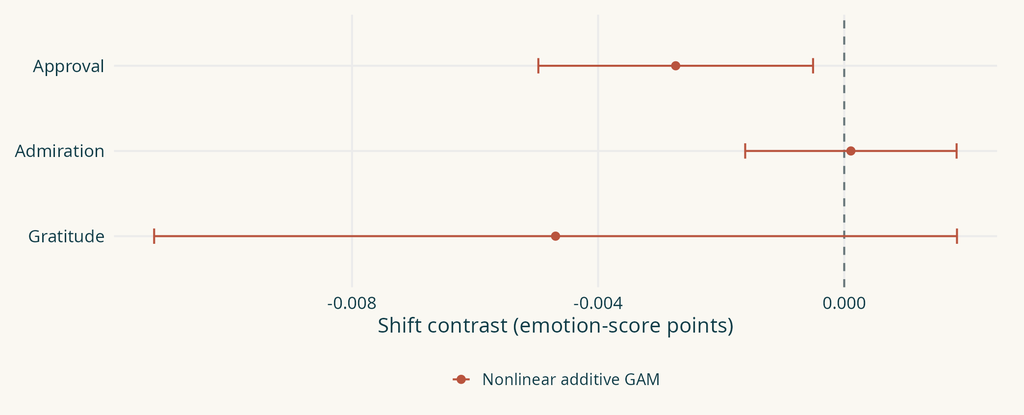

Main GAM; prior characteristics in original units. Average: 3,892 supported users with positive observed loss. Training: 15,982. 200 user draws; 95% pointwise intervals; fixed support and GAM basis/penalties.

Main GAM; prior characteristics in original units. Average: 3,892 supported users with positive observed loss. Training: 15,982. 200 user draws; 95% pointwise intervals; fixed support and GAM basis/penalties.

Approval has a negative GAM interval; admiration and gratitude remain uncertain.